# Extensions from LMM

## Checking residuals

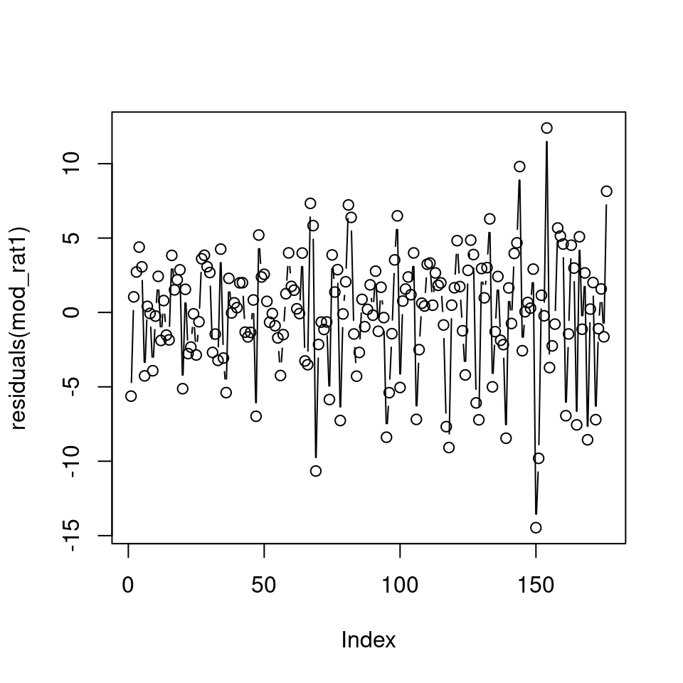

```r
plot(residuals(mod_rat1), type = "b")
```

## Fitting continuous temporal autocorrelation

```r
(mod_rat2 <- lme(weight ~ Diet * Time, random = ~ Time|Rat, correlation = corExp(form = ~ Time), data = body))
```

```
## Linear mixed-effects model fit by REML
##   Data: body
##   Log-restricted-likelihood: -566.0296
##   Fixed: weight ~ Diet * Time
## (Intercept)       Diet2       Diet3        Time  Diet2:Time  Diet3:Time
## 251.5924463 200.6889077 252.3152061   0.3602961   0.6255177   0.3109452
##
## Random effects:
##  Formula: ~Time | Rat
##  Structure: General positive-definite, Log-Cholesky parametrization
##             StdDev     Corr
## (Intercept) 36.9744887 (Intr)
## Time         0.2434607 -0.149
## Residual     4.5501283
##
## Correlation Structure: Exponential spatial correlation
##  Formula: ~Time | Rat
##  Parameter estimate(s):
##    range
## 3.650519
## Number of Observations: 176
## Number of Groups: 16
```

## Model comparison

```r
anova(mod_rat1, mod_rat2)
```

```
##          Model df      AIC      BIC    logLik   Test  L.Ratio p-value
## mod_rat1     1 10 1171.720 1203.078 -575.8599
## mod_rat2     2 11 1154.059 1188.553 -566.0296 1 vs 2 19.66057  <.0001
```

Note: the comparison makes sense as models are nested and fitted with REML.

## Alternative correlation structures

```r
mod_rat3 <- update(mod_rat1, corr = corExp(form = ~ Time, nugget = TRUE))
mod_rat4 <- update(mod_rat1, corr = corRatio(form = ~ Time))
mod_rat5 <- update(mod_rat1, corr = corSpher(form = ~ Time))
mod_rat6 <- update(mod_rat1, corr = corLin(form = ~ Time))
mod_rat7 <- update(mod_rat1, corr = corGaus(form = ~ Time))

rbind(mod_rat2 = AIC(mod_rat2),
      mod_rat3 = AIC(mod_rat3),
      mod_rat4 = AIC(mod_rat4),
      mod_rat5 = AIC(mod_rat5),
      mod_rat6 = AIC(mod_rat6),
      mod_rat7 = AIC(mod_rat7))
```

```
##              [,1]
## mod_rat2 1154.059
## mod_rat3 1151.768
## mod_rat4 1155.749
## mod_rat5 1157.233
## mod_rat6 1157.233
## mod_rat7 1157.233
```

## The best model

```r
mod_rat3
```

```
## Linear mixed-effects model fit by REML
##   Data: body
##   Log-restricted-likelihood: -563.8841
##   Fixed: weight ~ Diet * Time
## (Intercept)       Diet2       Diet3        Time  Diet2:Time  Diet3:Time
## 251.3005207 200.6582307 253.3068385   0.3623183   0.6421429   0.3063663
##
## Random effects:
##  Formula: ~Time | Rat
##  Structure: General positive-definite, Log-Cholesky parametrization
##             StdDev     Corr
## (Intercept) 36.9431391 (Intr)
## Time         0.2300954 -0.162
## Residual     5.7590445
##
## Correlation Structure: Exponential spatial correlation
##  Formula: ~Time | Rat
##  Parameter estimate(s):
##     range    nugget
## 17.150214  0.175613
## Number of Observations: 176
## Number of Groups: 16
```

## Same fit with `spaMM`

```r
(mod_rat_spaMM <- corrHLfit(weight ~ Diet * Time + (Time|Rat) + Matern(1|Time), data = body,
                            HLmethod = "REML", init.corrHLfit = list(Nugget = 0.1), ranFix = list(nu = 0.5)))
```

[output not shown]

## Fitted values: `nlme` vs `spaMM`

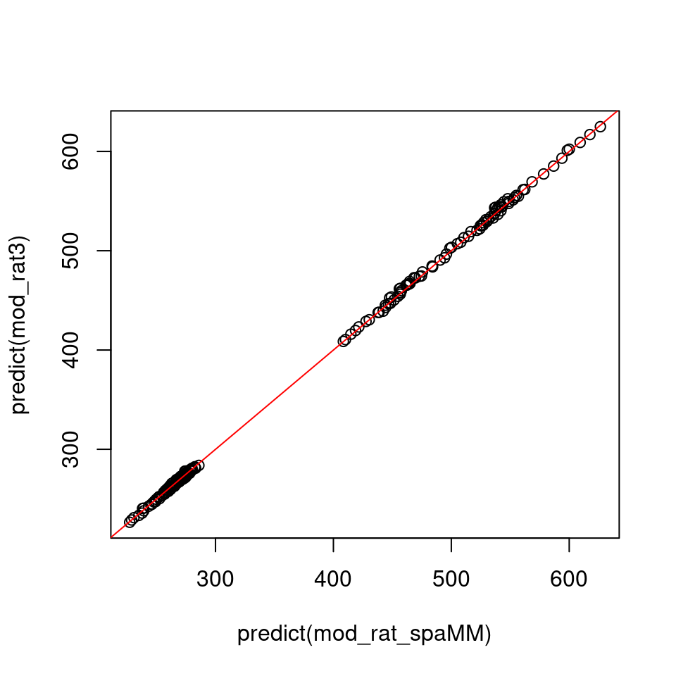

```r
plot(predict(mod_rat_spaMM), predict(mod_rat3))
abline(0, 1, col = "red")
```

## Better fit with `spaMM`?

```r
mod_rat_spaMM2 <- corrHLfit(weight ~ Diet * Time + (Time|Rat) + Matern(1|Time), data = body,
                            HLmethod = "REML", init.corrHLfit = list(Nugget = 0))

mod_rat_spaMM3 <- corrHLfit(weight ~ Diet * Time + (Time|Rat) + Matern(1|Time), data = body,
                            HLmethod = "REML", ranFix = list(Nugget = 0, nu = 0.5))
```

## Comparison between exponential and unconstrained Matern

```r
print(AIC(mod_rat_spaMM))
```

```
##        marginal AIC:     conditional AIC:      dispersion AIC:        effective df:
##            1176.1275            1035.8757            1149.1142             139.0042
```

```r
print(AIC(mod_rat_spaMM2))
```

```
##        marginal AIC:     conditional AIC:      dispersion AIC:        effective df:
##            1175.7517            1035.7574            1148.7629             139.3773
```

```r
print(AIC(mod_rat_spaMM3))
```

```
##        marginal AIC:     conditional AIC:      dispersion AIC:        effective df:
##            1176.1275            1035.8757            1149.1142             139.0042
```

## Displaying the continuous correlation function

[figure not shown]

```r
time.pred <- seq(0, 64, 0.1)
corr <- MaternCorr(time.pred, rho = mod_rat_spaMM$corrPars$rho, nu = 0.5, Nugget = mod_rat_spaMM$corrPars$Nugget)
plot(corr ~ time.pred, xlab = "Time (days)", ylab = "Correlation", type = "l")
```

## Testing the overall effect of diet

### `spaMM`

```r
mod_rat_spaMM3ML <- corrHLfit(weight ~ Diet * Time + (Time|Rat) + Matern(1|Time), data = body,
                            HLmethod = "ML", ranFix = list(Nugget = 0, nu = 0.5))
mod_rat_no_diet <- corrHLfit(weight ~ 1 + Time + (Time|Rat) + Matern(1|Time), data = body,
                            HLmethod = "ML", ranFix = list(Nugget = 0, nu = 0.5))
```

```r
anova(mod_rat_spaMM3ML, mod_rat_no_diet)
```

```
##     chi2_LR df      p_value
## p_v 47.5844  4 1.152112e-09
```

```r
c(logLik(mod_rat_spaMM3ML), logLik(mod_rat_no_diet))
```

```
##       p_v       p_v
## -576.8528 -600.6450
```

## Testing the overall effect of diet

### `nlme`

```r
mod_rat3ML <- lme(weight ~ Diet * Time, random = ~ Time|Rat,
                  correlation = corExp(form = ~ Time, nugget = TRUE), data = body, method = "ML")

mod_rat_no_diet2 <- lme(weight ~ 1 + Time, random = ~ Time|Rat,
                        correlation = corExp(form = ~ Time, nugget = TRUE), data = body, method = "ML")
```

```r
anova(mod_rat3ML, mod_rat_no_diet2)
```

```
##                  Model df      AIC      BIC    logLik   Test  L.Ratio p-value
## mod_rat3ML           1 12 1165.962 1204.007 -570.9808
## mod_rat_no_diet2     2  8 1206.618 1231.982 -595.3088 1 vs 2 48.65601  <.0001
```

## Revisiting the airplane passengers with `spaMM::fitme()`

```r
air$time <- seq(1949, 1960, length = (1960 - 1949 + 1) * 12)

mod_air_spaMM1 <- fitme(passengers ~ month * year + Matern(1|time), data = air, method = "REML")

mod_air_spaMM2 <- fitme(passengers ~ month * year + Matern(1|time), data = air, method = "REML",
                        init = list(Nugget = 0))

mod_air_spaMM3 <- fitme(passengers ~ month * year + Matern(1|time), data = air, method = "REML",
                        init = list(Nugget = 0), fixed = list(nu = 0.5))

mod_air_spaMM4 <- fitme(passengers ~ month * year + Matern(1|time), data = air, method = "REML",
                        fixed = list(nu = 0.5, Nugget = 0))
```

## Models comparison (NOTE: CHECK THIS AGAIN LATER WITH FRANCOIS.. I changed the model to include the interaction and results are now strange…)

```r
print(AIC(mod_air_spaMM1))
```

```
##        marginal AIC:     conditional AIC:      dispersion AIC:        effective df:
##           1059.53214           1050.95969            944.89040             40.40634
```

```r
print(AIC(mod_air_spaMM2))
```

```
##        marginal AIC:     conditional AIC:      dispersion AIC:        effective df:
##            1059.5322           -3290.7112             944.8904            2112.9078
```

```r
print(AIC(mod_air_spaMM3))
```

```
##        marginal AIC:     conditional AIC:      dispersion AIC:        effective df:
##            1059.8193             433.1474             944.9038             352.5986
```

```r
print(AIC(mod_air_spaMM4))
```

```
##        marginal AIC:     conditional AIC:      dispersion AIC:        effective df:
##            1059.8193             433.4605             944.9038             352.4420
```

## Examining the best model

```r
mod_air_spaMM2
```

```
## formula: passengers ~ month * year + Matern(1 | time)
## REML: Estimation of lambda, phi and corrPars by REML.
##       Estimation of fixed effects by ML.
## Family: gaussian ( link = identity )
##  ------------ Fixed effects (beta) ------------
##                Estimate  Cond. SE  t-value
## (Intercept)  -5.489e+04 8335.2765  -6.5851
## month2        6.660e+03 1524.5450   4.3685
## month3        8.221e+02 1663.6955   0.4942
## month4       -2.204e+03 1765.2105  -1.2486
## month5       -6.056e+03 1836.5715  -3.2974
## month6       -1.633e+04 1881.7318  -8.6785
## month7       -2.811e+04 1902.7974 -14.7724
## month8       -2.722e+04 1900.6447 -14.3228
## month9       -9.880e+03 1875.1311  -5.2692
## month10      -2.489e+03 1825.0470  -1.3637
## month11       6.115e+03 1747.7603   3.4987
## month12       2.269e+03 1638.1528   1.3853
## year          2.822e+01    4.2634   6.6185
## month2:year  -3.411e+00    0.7800  -4.3730
## month3:year  -4.061e-01    0.8512  -0.4771
## month4:year   1.141e+00    0.9031   1.2629
## month5:year   3.114e+00    0.9397   3.3138
## month6:year   8.391e+00    0.9628   8.7157
## month7:year   1.444e+01    0.9735  14.8300
## month8:year   1.398e+01    0.9724  14.3804
## month9:year   5.086e+00    0.9594   5.3015
## month10:year  1.286e+00    0.9338   1.3774
## month11:year -3.133e+00    0.8942  -3.5038
## month12:year -1.151e+00    0.8381  -1.3730
##  --------------- Random effects ---------------
## Family: gaussian ( link = identity )
##                    --- Correlation parameters:
##   1.Nugget       1.nu      1.rho
## 0.00177550 0.47908575 0.00915493
##            --- Variance parameters ('lambda'):
## lambda = var(u) for u ~ Gaussian;
##    time  :  11990
##              --- Coefficients for log(lambda):
##  Group        Term Estimate Cond.SE
##   time (Intercept)    9.391   0.146
## # of obs: 144; # of groups: time, 144
##  ------------- Residual variance  -------------
## Coefficients for log(phi) ~ 1 :
##             Estimate Cond. SE
## (Intercept)     2.46   0.2766
## Estimate of phi=residual var:  11.71
##  ------------- Likelihood values  -------------
##                         logLik
## p_v(h) (marginal L): -503.7661
##   p_beta,v(h) (ReL): -470.4452
```

## Fitted values

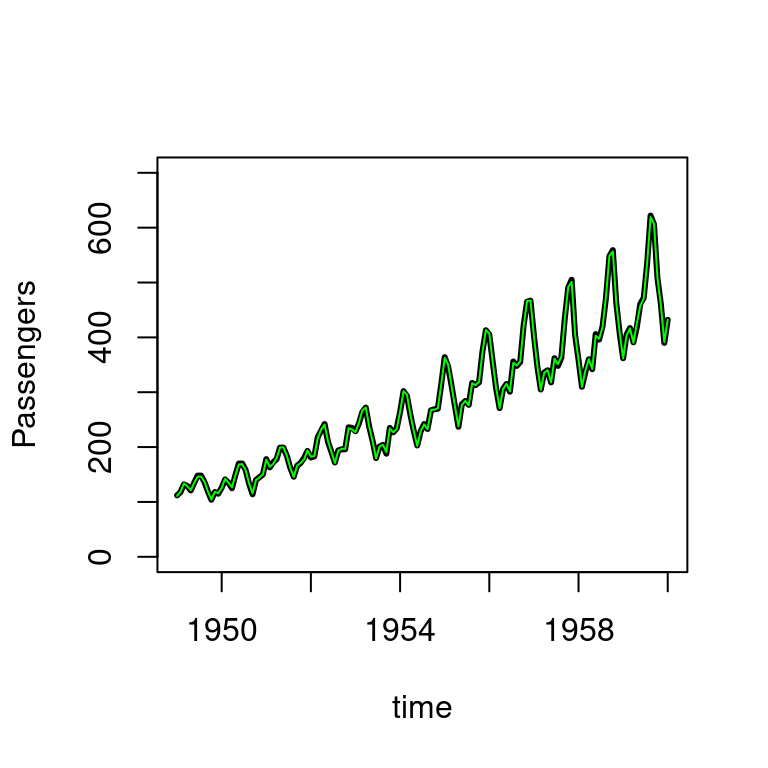

```r
data.for.plot$pred_spaMM <- predict(mod_air_spaMM2)
plot(obs ~ time, data = data.for.plot, type = "l", lwd = 3, ylim = c(0, 700), ylab = "Passengers")
points(pred_spaMM ~ time, data = data.for.plot, type = "l", col = "green")
```

Note: never extrapolate using such model! The perfect fit is not unusual.

## Testing the effect of years

### `spaMM`

```r
mod_air_spaMM2ML <- fitme(passengers ~ month + year + Matern(1|time), data = air, method = "ML",
                        init = list(Nugget = 0))
```

[output not shown]

```r
mod_air_no_year <- fitme(passengers ~ month + Matern(1|time), data = air, method = "ML",
                        init = list(Nugget = 0))
```

```r
anova(mod_air_spaMM2ML, mod_air_no_year)
```

```
##      chi2_LR df      p_value
## p_v 38.93689  1 4.377311e-10
```

```r
c(logLik(mod_air_spaMM2ML), logLik(mod_air_no_year))
```

```
##       p_v       p_v
## -593.5887 -613.0572
```

## Testing the effect of years

### `nlme`

```r
mod_air3ML <- lme(passengers ~ month + year, random = ~ 1 | year, data = air,
                 correlation = corARMA(p = 6, q = 0), method = "ML")

mod_air_no_year2 <- lme(passengers ~ month, random = ~ 1 | year, data = air,
                 correlation = corARMA(p = 6, q = 0), method = "ML")
```

```r
anova(mod_air3ML, mod_air_no_year2)
```

```
##                  Model df      AIC      BIC    logLik   Test L.Ratio p-value
## mod_air3ML           1 21 1209.245 1271.611 -583.6224
## mod_air_no_year2     2 20 1258.970 1318.367 -609.4851 1 vs 2 51.7254  <.0001
```

## Spatial autocorrelation

## Maximum normalised-difference vegetation index in north Cameroon

```r
data("Loaloa")
ndvi <- Loaloa[, c("maxNDVI", "latitude", "longitude")]
head(ndvi)
```

```
##    maxNDVI latitude longitude
## X1    0.69 5.736750  8.041860
## X2    0.74 5.680280  8.004330
## X3    0.79 5.347222  8.905556
## X4    0.67 5.917420  8.100720
## X5    0.85 5.104540  8.182510
## X6    0.80 5.355556  8.929167
```

## Visualising the data

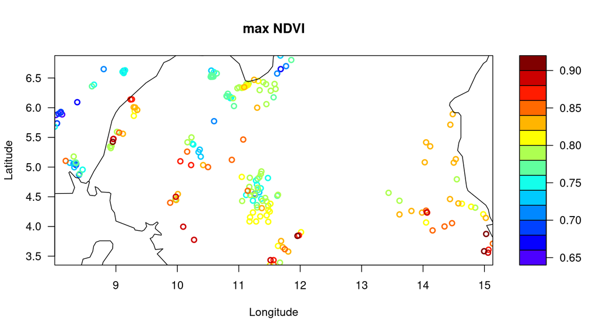

```r
library(maps)
spaMMplot2D(x = ndvi$longitude, y = ndvi$latitude, z = ndvi$maxNDVI, add.map = TRUE,
            xlab = "Longitude", ylab = "Latitude", plot.title = title(main = "max NDVI"))
```

## Visualising the data

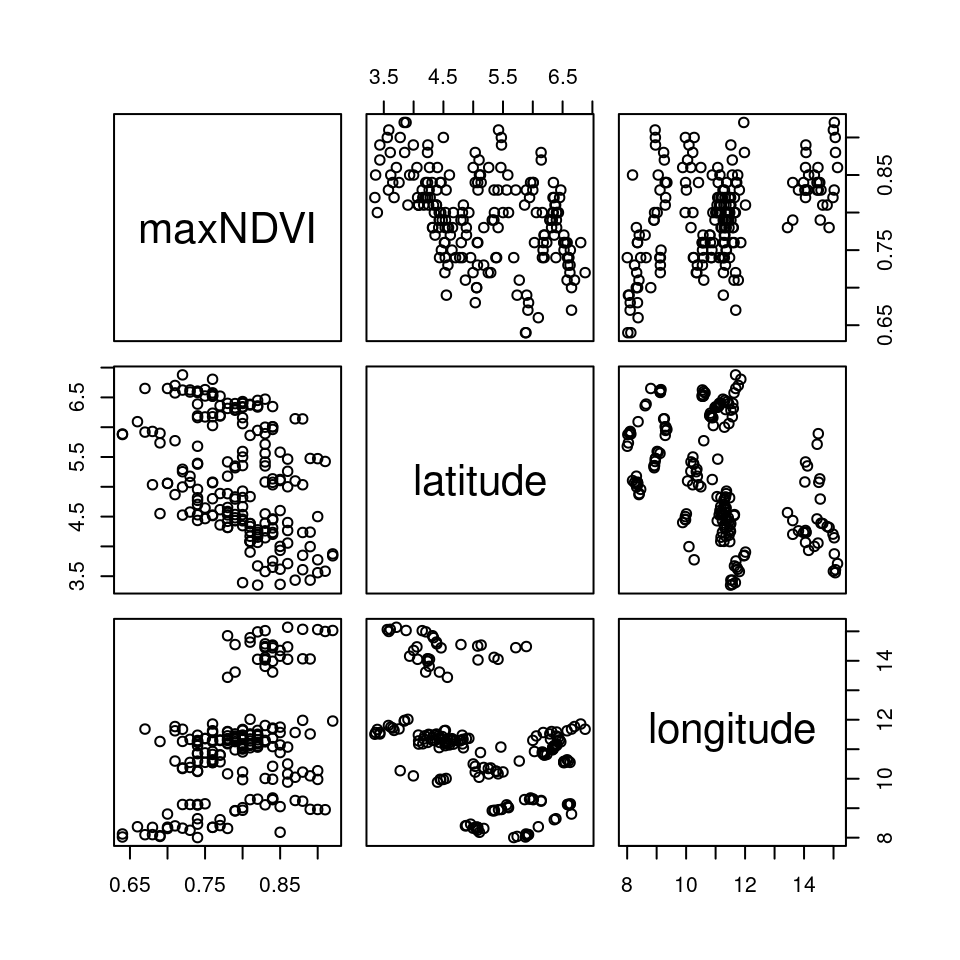

```r
pairs(ndvi)
```

## Fitting the model

```r
(mod_ndvi1 <- fitme(maxNDVI ~ 1 + Matern(1|longitude + latitude), data = ndvi, method = "REML"))
```

```
## formula: maxNDVI ~ 1 + Matern(1 | longitude + latitude)
## REML: Estimation of lambda, phi and corrPars by REML.
##       Estimation of fixed effects by ML.
## Family: gaussian ( link = identity )
##  ------------ Fixed effects (beta) ------------
##             Estimate Cond. SE t-value
## (Intercept)   0.8006  0.02392   33.47
##  --------------- Random effects ---------------
## Family: gaussian ( link = identity )
##                    --- Correlation parameters:
##      1.nu     1.rho
## 0.4066063 0.9341279
##            --- Variance parameters ('lambda'):
## lambda = var(u) for u ~ Gaussian;
##    longitude.  :  0.004323
##              --- Coefficients for log(lambda):
##       Group        Term Estimate Cond.SE
##  longitude. (Intercept)   -5.444  0.1229
## # of obs: 197; # of groups: longitude., 197
##  ------------- Residual variance  -------------
## Coefficients for log(phi) ~ 1 :
##             Estimate Cond. SE
## (Intercept)   -8.219   0.1775
## Estimate of phi=residual var:  0.0002695
##  ------------- Likelihood values  -------------
##                        logLik
## p_v(h) (marginal L): 378.1402
##   p_beta,v(h) (ReL): 375.3261
```

## Predictions

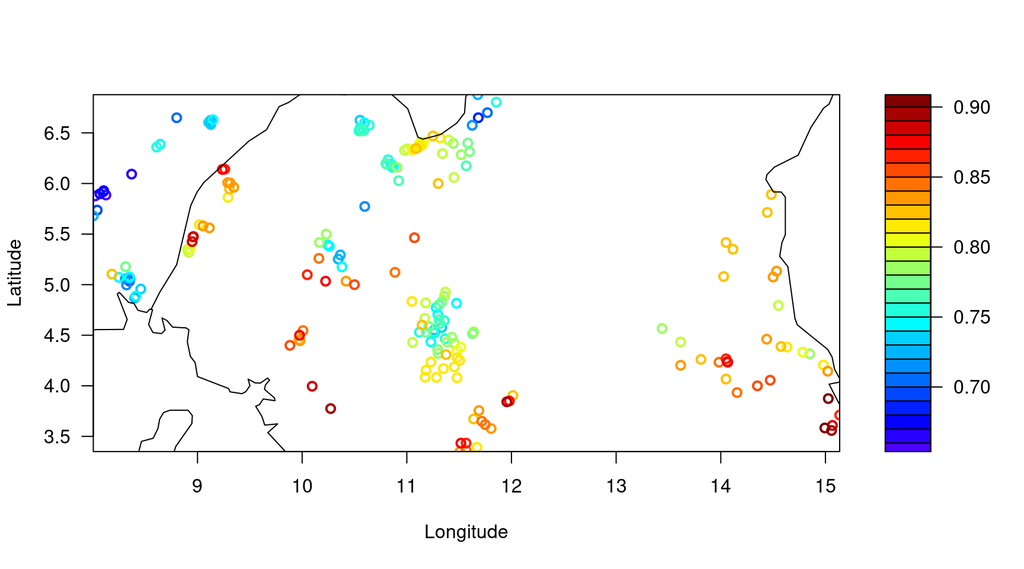

```r
mapMM(mod_ndvi1, add.map = TRUE, plot.title = title(xlab = "Longitude", ylab = "Latitude"))
```

## Predictions

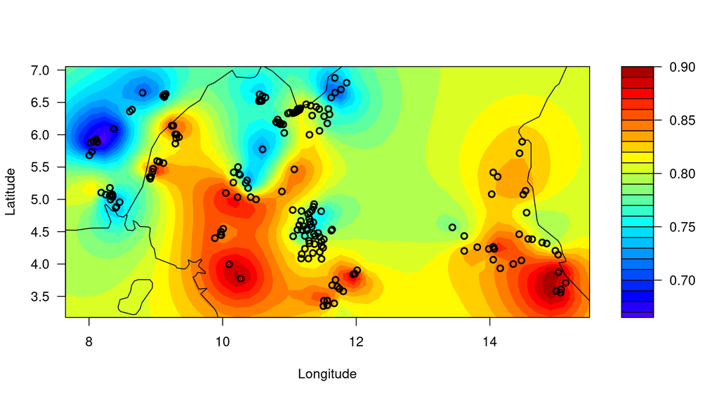

```r
filled.mapMM(mod_ndvi1, add.map = TRUE, plot.title = title(xlab = "Longitude", ylab = "Latitude"))
```

## Prediction uncertainty

```r
x.for.pred <- seq(min(ndvi$longitude), max(ndvi$longitude), length.out = 100)
y.for.pred <- seq(min(ndvi$latitude), max(ndvi$latitude), length.out = 50)
data.for.pred <- expand.grid(longitude = x.for.pred, latitude = y.for.pred)
gridpred <- predict(mod_ndvi1, newdata = data.for.pred, variances = list(predVar = TRUE))
data.for.pred$predVar <- attr(gridpred, "predVar")
m <- matrix(data.for.pred$predVar, ncol = length(y.for.pred))
```

## Prediction uncertainty

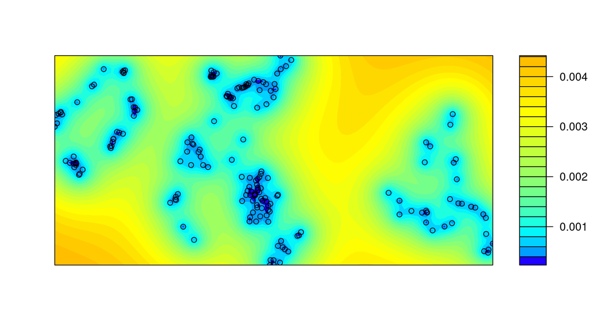

```r
spaMM.filled.contour(x = x.for.pred, y = y.for.pred, z = m, plot.axes = {
  points(ndvi[, c("longitude", "latitude")])}, col = spaMM.colors(redshift = 3))
```

## Non gaussian response

## GLMM

### GLM + LMM = GLMM

\[\begin{array}{lcl} \mu &=& g^{-1}(\eta)\\ \mu &=& g^{-1}(\mathbf{X}\beta + \mathbf{Z}b)\\ \end{array} \]

with (as for GLM):

- \(\text{E}(\text{Y}) = \mu = g^{-1}(\eta)\)
- \(\text{Var}(\text{Y}) = \phi\text{V}(\mu)\)

Note:

- If \(g^{-1}\) is the identity function, \(\phi = \sigma^2\) and \(\text{V}(\mu) = 1\), we have the LMM.
- If \(\mathbf{Z}b = 0\), we have the GLM.
- If \(g^{-1}\) is the identity function, \(\phi = \sigma^2\), \(\text{V}(\mu) = 1\), and \(\mathbf{Z}b = 0\), we have the LM.

## The `LM2GLMM::Flatwork` dataset

```r
Flatwork
```

```
##    individual gender month shopping cleaning other absent
## 1           1      w   nov        4        8     3      0
## 2           2      w   nov       10        5    10      7
## 3           3      w   nov        3        1     2      4
## 4           4      w   nov       15        2     0      0
## 5           5      w   nov       15        9     4      0
## 6           6      m   nov        0        2     8      0
## 7           7      w   nov        5        6     6     10
## 8           8      m   nov        3        4     5     11
## 9           9      m   nov        5        7     6      4
## 10         10      m   nov        6        3     0      7
## 11          1      w   dec        7        6     3      1
## 12          2      w   dec        6        2     3      7
## 13          3      w   dec        5        7     1      5
## 14          4      w   dec       14        5     1      0
```

[output cut: 46 more lines]

## The `LM2GLMM::Flatwork` dataset

```r
str(Flatwork)
```

```
## 'data.frame':    60 obs. of  7 variables:
##  $ individual: int  1 2 3 4 5 6 7 8 9 10 ...
##  $ gender    : Factor w/ 2 levels "m","w": 2 2 2 2 2 1 2 1 1 1 ...
##  $ month     : Factor w/ 6 levels "apr","dec","feb",..: 6 6 6 6 6 6 6 6 6 6 ...
##  $ shopping  : int  4 10 3 15 15 0 5 3 5 6 ...
##  $ cleaning  : int  8 5 1 2 9 2 6 4 7 3 ...
##  $ other     : int  3 10 2 0 4 8 6 5 6 0 ...
##  $ absent    : int  0 7 4 0 0 0 10 11 4 7 ...
```

## GLMM with `lme4`

```r
(mod_glmm_lme4 <- glmer(shopping ~ gender + (1|individual) + (1|month), family = poisson(),
                        data = Flatwork))
```

```
## Generalized linear mixed model fit by maximum likelihood (Laplace Approximation) ['glmerMod']
##  Family: poisson  ( log )
## Formula: shopping ~ gender + (1 | individual) + (1 | month)
##    Data: Flatwork
##       AIC       BIC    logLik  deviance  df.resid
##  421.7239  430.1012 -206.8619  413.7239        56
## Random effects:
##  Groups     Name        Std.Dev.
##  individual (Intercept) 0.2261
##  month      (Intercept) 0.0510
## Number of obs: 60, groups:  individual, 10; month, 6
## Fixed Effects:
## (Intercept)      genderw
##      1.7107       0.2159
```

## GLMM with `spaMM`

```r
(mod_glmm_spaMM <- fitme(shopping ~ gender + (1|individual) + (1|month), family = poisson(),
                        data = Flatwork, method = "ML"))
```

```
## formula: shopping ~ gender + (1 | individual) + (1 | month)
## Estimation of corrPars and lambda by Laplace ML approximation (p_v).
## Estimation of fixed effects by Laplace ML approximation (p_v).
## Estimation of lambda by 'outer' ML, maximizing p_v.
## Family: poisson ( link = log )
##  ------------ Fixed effects (beta) ------------
##             Estimate Cond. SE t-value
## (Intercept)   1.7107   0.1440  11.879
## genderw       0.2159   0.1813   1.191
##  --------------- Random effects ---------------
## Family: gaussian ( link = identity )
##            --- Variance parameters ('lambda'):
## lambda = var(u) for u ~ Gaussian;
##    individual  :  0.05113
##    month  :  0.002602
## # of obs: 60; # of groups: individual, 10; month, 6
##  ------------- Likelihood values  -------------
##                         logLik
## p_v(h) (marginal L): -206.8619
```

## Checking residuals

```
## DHARMa::plotResiduals - low number of unique predictor values, consider setting asFactor = T
## DHARMa::plotResiduals - low number of unique predictor values, consider setting asFactor = T
```

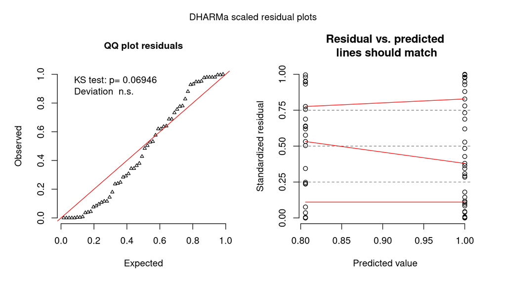

```r
library(DHARMa)
r <- simulateResiduals(mod_glmm_lme4)
plot(r)
```

## Extra 0s?

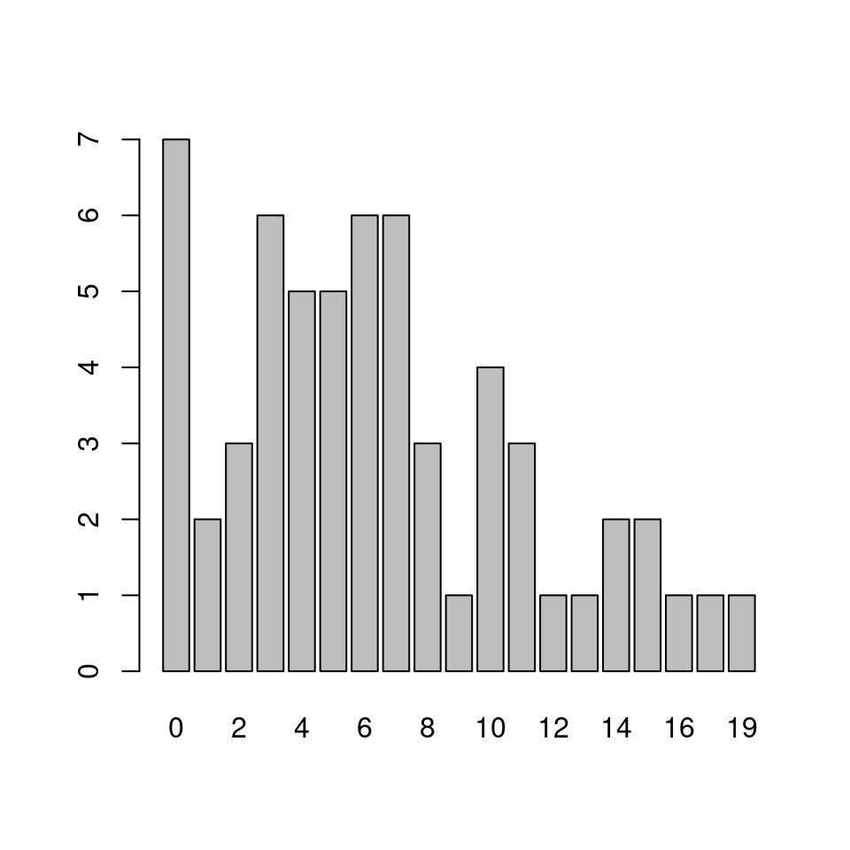

```r
barplot(table(Flatwork$shopping))
```

## Extra 0s?

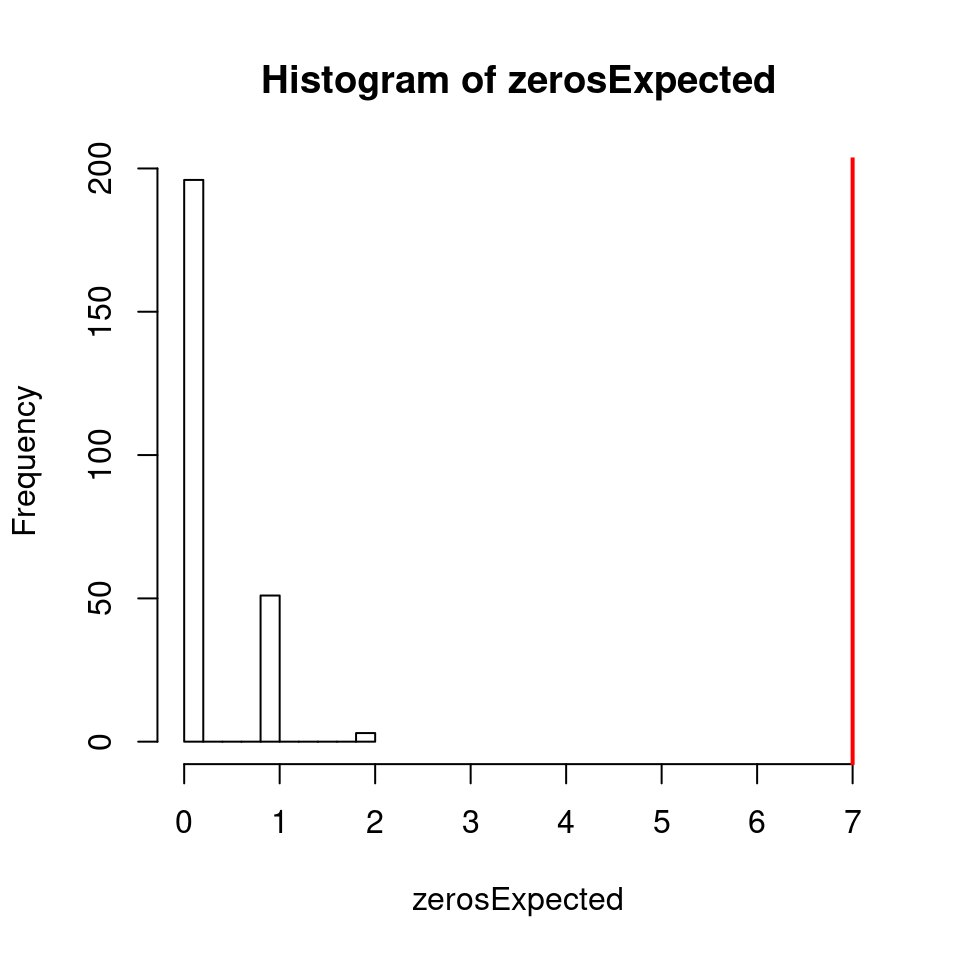

```
##
##  DHARMa zero-inflation test via comparison to expected zeros with simulation under H0 =
##  fitted model
##
## data:  r
## ratioObsExp = 30.702, p-value < 2.2e-16
## alternative hypothesis: more
```

```r
testZeroInflation(r)
```

## Binomial model

```r
Flatwork$shopping_bin <- Flatwork$shopping > 0
(mod_glmm_lme4bin <- glmer(shopping_bin ~ gender + (1|individual) + (1|month), family = binomial(),
                        data = Flatwork))
```

```
## Generalized linear mixed model fit by maximum likelihood (Laplace Approximation) ['glmerMod']
##  Family: binomial  ( logit )
## Formula: shopping_bin ~ gender + (1 | individual) + (1 | month)
##    Data: Flatwork
##      AIC      BIC   logLik deviance df.resid
##  50.2791  58.6565 -21.1396  42.2791       56
## Random effects:
##  Groups     Name        Std.Dev.
##  individual (Intercept) 8.887e-09
##  month      (Intercept) 4.127e-08
## Number of obs: 60, groups:  individual, 10; month, 6
## Fixed Effects:
## (Intercept)      genderw
##      1.6094       0.7885
```

## Checking residuals

```
## DHARMa::plotResiduals - low number of unique predictor values, consider setting asFactor = T
## DHARMa::plotResiduals - low number of unique predictor values, consider setting asFactor = T
```

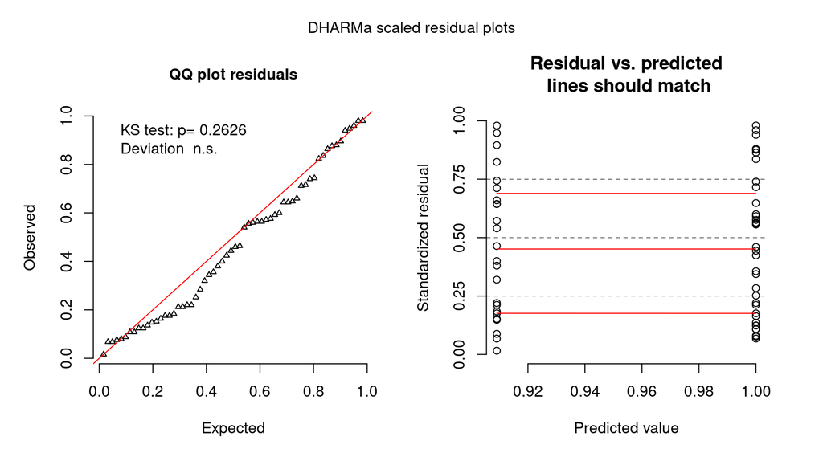

```r
r_bin <- simulateResiduals(mod_glmm_lme4bin)
plot(r_bin)
```

## Overdispersion?

```r
r_bin2 <- simulateResiduals(mod_glmm_lme4bin, refit = TRUE)  ## slow and convergence issues...
testOverdispersion(r_bin2)
```

```
##
##  DHARMa nonparametric overdispersion test via comparison to simulation under H0 = fitted
##  model
##
## data:  r_bin2
## dispersion = 1.2008, p-value = 0.064
## alternative hypothesis: overdispersion
```

## Testing the gender effect

```r
mod_glmm_lme4bin0 <- glmer(shopping_bin ~ 1 + (1|individual) + (1|month), family = binomial(),
                        data = Flatwork)

anova(mod_glmm_lme4bin, mod_glmm_lme4bin0)
```

```
## Data: Flatwork
## Models:
## mod_glmm_lme4bin0: shopping_bin ~ 1 + (1 | individual) + (1 | month)
## mod_glmm_lme4bin: shopping_bin ~ gender + (1 | individual) + (1 | month)
##                   Df    AIC    BIC  logLik deviance  Chisq Chi Df Pr(>Chisq)
## mod_glmm_lme4bin0  3 49.228 55.511 -21.614   43.228
## mod_glmm_lme4bin   4 50.279 58.657 -21.140   42.279 0.9485      1     0.3301
```

## Same with `spaMM`

```r
mod_glmm_spaMMbin <- fitme(shopping_bin ~ gender + (1|individual) + (1|month), family = binomial(),
                        data = Flatwork)
```

```
## Fits using Laplace approximation may diverge for all-or-none binomial data:
##  check PQL or PQL/L methods in that case.
```

```r
mod_glmm_spaMMbin0 <- fitme(shopping_bin ~ 1 + (1|individual) + (1|month), family = binomial(),
                        data = Flatwork)

anova(mod_glmm_spaMMbin, mod_glmm_spaMMbin0)
```

```
##       chi2_LR df   p_value
## p_v 0.9485333  1 0.3300929
```

## Is there an effect for the non-zeros?

This is not ideal, but we will try an analysis on the truncated distribution…

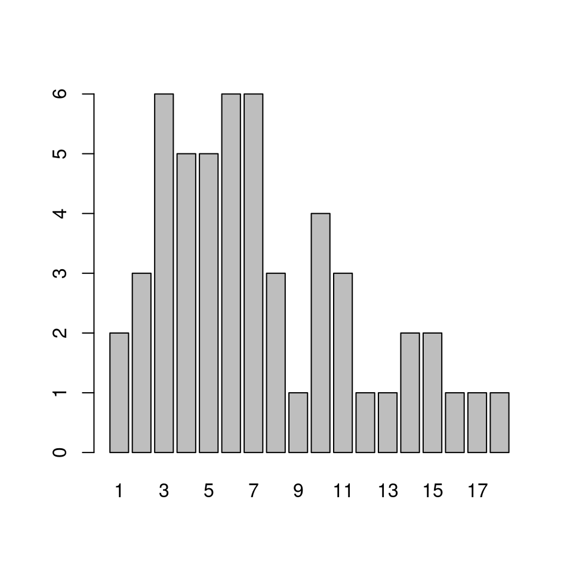

```r
Flatwork_pos <- subset(Flatwork, Flatwork$shopping_bin)
barplot(table(Flatwork_pos$shopping))
```

## Fitting models on truncated distributions

```r
mod_glmm_lme4pos1 <- glmer(shopping ~ gender + (1|individual) + (1|month), family = poisson(),
                        data = Flatwork_pos)
mod_glmm_lme4pos2 <- glmer.nb(shopping ~ gender + (1|individual) + (1|month), data = Flatwork_pos)
mod_glmm_spaMMpos1 <- fitme(shopping ~ gender + (1|individual) + (1|month), family = poisson(),
                        data = Flatwork_pos)
mod_glmm_spaMMpos2 <- fitme(shopping ~ gender + (1|individual) + (1|month), family = spaMM::negbin(),
                        data = Flatwork_pos)
mod_glmm_spaMMpos3 <- fitme(shopping ~ gender + (1|individual) + (1|month), family = COMPoisson(),
                        data = Flatwork_pos)

c(AIC(mod_glmm_lme4pos1), AIC(mod_glmm_lme4pos2))
```

```
## [1] 328.9853 306.3538
```

```r
print(c(AIC(mod_glmm_spaMMpos1), AIC(mod_glmm_spaMMpos2), AIC(mod_glmm_spaMMpos3)))
```

```
##        marginal AIC: 328.98531
##     conditional AIC: 318.21443
##      dispersion AIC: 324.98531
##        effective df:  43.82578
##        marginal AIC: 306.35383
##     conditional AIC: 302.35376
##      dispersion AIC: 302.35383
##        effective df:  50.99975
##        marginal AIC: 359.00219
##     conditional AIC: 347.61158
##      dispersion AIC: 355.00219
##        effective df:  41.75854
##        marginal AIC:     conditional AIC:      dispersion AIC:        effective df:
##            328.98531            318.21443            324.98531             43.82578
##        marginal AIC:     conditional AIC:      dispersion AIC:        effective df:
##            306.35383            302.35376            302.35383             50.99975
##        marginal AIC:     conditional AIC:      dispersion AIC:        effective df:
##            359.00219            347.61158            355.00219             41.75854
```

## Checking residuals

```
## DHARMa::plotResiduals - low number of unique predictor values, consider setting asFactor = T
## DHARMa::plotResiduals - low number of unique predictor values, consider setting asFactor = T
```

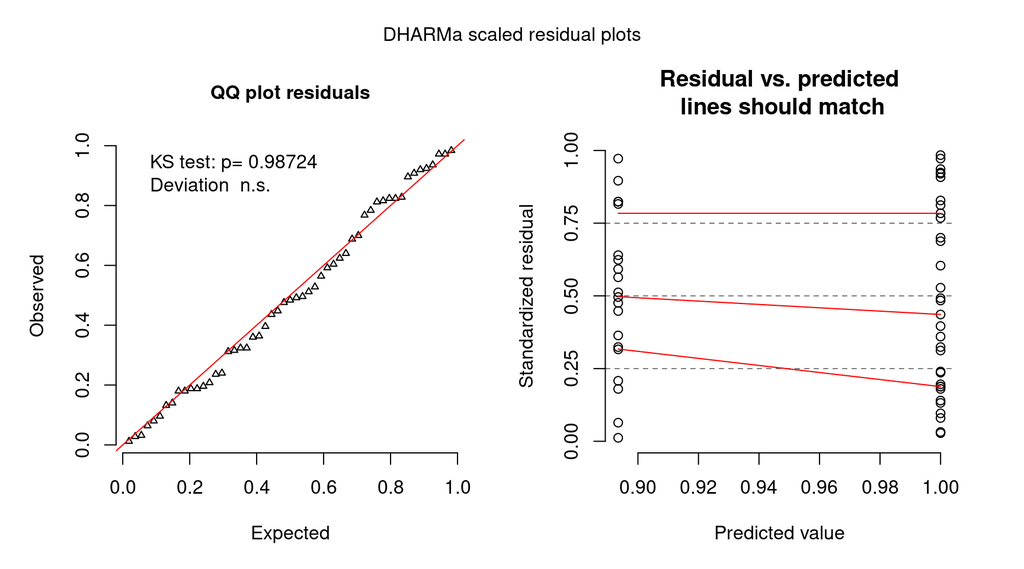

```r
r_pos <- simulateResiduals(mod_glmm_lme4pos2)
plot(r_pos)
```

## Testing again the gender effect

```r
mod_glmm_spaMMpos20 <- fitme(shopping ~ 1 + (1|individual) + (1|month), family = spaMM::negbin(),
                        data = Flatwork_pos)

anova(mod_glmm_spaMMpos20, mod_glmm_spaMMpos2)
```

```
##       chi2_LR df   p_value
## p_v 0.4453586  1 0.5045474
```

## Practice

What about gender and cleaning?

## Non gaussian random effects

## The Hierarchical GLM (HGLM)

\[\begin{array}{lcl} \mu &=& g^{-1}(\eta)\\ \mu &=& g^{-1}(\mathbf{X}\beta + \mathbf{Z}b)\\ \mu &=& g^{-1}(\mathbf{X}\beta + \mathbf{Z}f(u)) \end{array} \]

Note:

- If \(f(u)\) is the identity function and \(u\) is drawn for a normal distribution, then we have the GLMM, a particular case of the more general HGLM.
- Hence LM, GLM, LMM and GLMM are all particular cases of the HGLM.

## The example of the negative binomial

```r
library(MASS)

mod_negbin <- glm.nb(Days ~ Sex/Age, data = quine)

quine$index <- factor(1:nrow(quine))

mod_poiss_gamma <- fitme(Days ~ Sex/Age + (1|index), data = quine,
                         family = poisson(), rand.family = Gamma("log"))

rbind(mod_negbin$coefficients, mod_poiss_gamma$fixef)
```

```
##      (Intercept)       SexM SexF:AgeF1 SexM:AgeF1  SexF:AgeF2 SexM:AgeF2 SexF:AgeF3 SexM:AgeF3
## [1,]    2.928524 -0.3957609 -0.3659809 -0.5868525 -0.01502935  0.6211936 -0.2894662  0.7709794
## [2,]    2.928524 -0.3957609 -0.3659809 -0.5868525 -0.01502935  0.6211936 -0.2894662  0.7709794
```

Note: the equivalence is expected! In more complex models differences may appear.

## The beta-binomial HGLM

\[ \begin{array}{lcl} \text{logit}(p) &=& \text{ln}\left(\frac{p}{1-p}\right) = \mathbf{X}\beta + \mathbf{Z}b\\ \text{logit}(b) &=& \text{ln}\left(\frac{u}{1-u}\right) \end{array} \]

with \(u\) following the beta distribution.

It can be useful to model heterogeneity in proportions!

## The `spaMM::seeds` dataset

```r
data(seeds)
seeds
```

```
##    plate seed  extract  r  n
## 1      1  O75     Bean 10 39
## 2      2  O75     Bean 23 62
## 3      3  O75     Bean 23 81
## 4      4  O75     Bean 26 51
## 5      5  O75     Bean 17 39
## 6      6  O73     Bean  8 16
## 7      7  O73     Bean 10 30
## 8      8  O73     Bean  8 28
## 9      9  O73     Bean 23 45
## 10    10  O73     Bean  0  4
## 11    11  O75 Cucumber  5  6
## 12    12  O75 Cucumber 53 74
## 13    13  O75 Cucumber 55 72
## 14    14  O75 Cucumber 32 51
## 15    15  O75 Cucumber 46 79
## 16    16  O75 Cucumber 10 13
## 17    17  O73 Cucumber  3 12
## 18    18  O73 Cucumber 22 41
## 19    19  O73 Cucumber 15 30
## 20    20  O73 Cucumber 32 51
## 21    21  O73 Cucumber  3  7
```

## The `spaMM::seeds` dataset

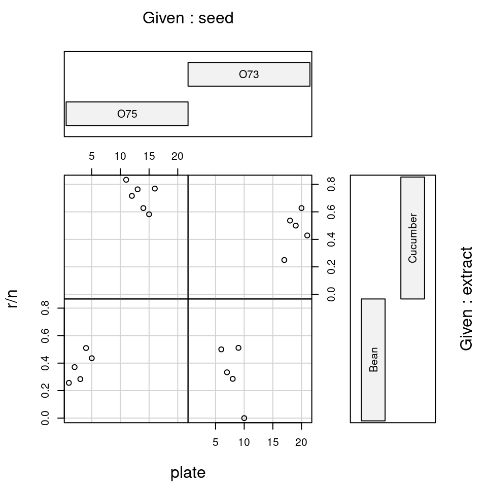

```r
coplot(r/n ~ plate | seed + extract, data = seeds)
```

## Fitting the germination data using the HGLM

```r
(mod_germ1 <- fitme(cbind(r, n - r) ~ seed * extract + (1|plate), family = binomial(), rand.family = Beta(),
                   data = seeds, method = "REML"))
```

```
## formula: cbind(r, n - r) ~ seed * extract + (1 | plate)
## Estimation of lambda by Laplace REML approximation (p_bv).
## Estimation of fixed effects by Laplace ML approximation (p_v).
## Family: binomial ( link = logit )
##  ------------ Fixed effects (beta) ------------
##                         Estimate Cond. SE t-value
## (Intercept)              -0.5483   0.1896 -2.8922
## seedO73                   0.0768   0.3070  0.2502
## extractCucumber           1.3526   0.2687  5.0330
## seedO73:extractCucumber  -0.8313   0.4279 -1.9429
##  --------------- Random effects ---------------
## Family: Beta ( link = logit )
##            --- Variance parameters ('lambda'):
## lambda = 4 var(u)/(1 - 4 var(u)) for u ~ Beta[1/(2*lambda),1/(2*lambda)];
##    plate  :  0.02378
##              --- Coefficients for log(lambda):
##  Group        Term Estimate Cond.SE
##  plate (Intercept)   -3.739  0.5364
## # of obs: 21; # of groups: plate, 21
##  ------------- Likelihood values  -------------
##                         logLik
## p_v(h) (marginal L): -54.05829
##   p_beta,v(h) (ReL): -56.59763
```

## Comparison to the binomial GLMM

```r
mod_germ2 <- fitme(cbind(r, n - r) ~ seed * extract + (1|plate), family = binomial(),
                   data = seeds, method = "REML")

print(rbind(AIC(mod_germ1), AIC(mod_germ2)))
```

```
##             marginal AIC:     conditional AIC:      dispersion AIC:        effective df:
## [1,]             118.1166             110.5305             115.1953            10.116005
## [2,]             118.0763             110.5009             115.0612             9.939376
```

Ok… here it does not do much difference, but it is still worth trying.

## Heteroscedasticity

## Let's revisit the rats

```r
mod_rat_spaMM <- corrHLfit(weight ~ Diet * Time + (Time|Rat) + Matern(1|Time), data = body,
                            HLmethod = "REML", init.corrHLfit = list(Nugget = 0.1), ranFix = list(nu = 0.5))
```

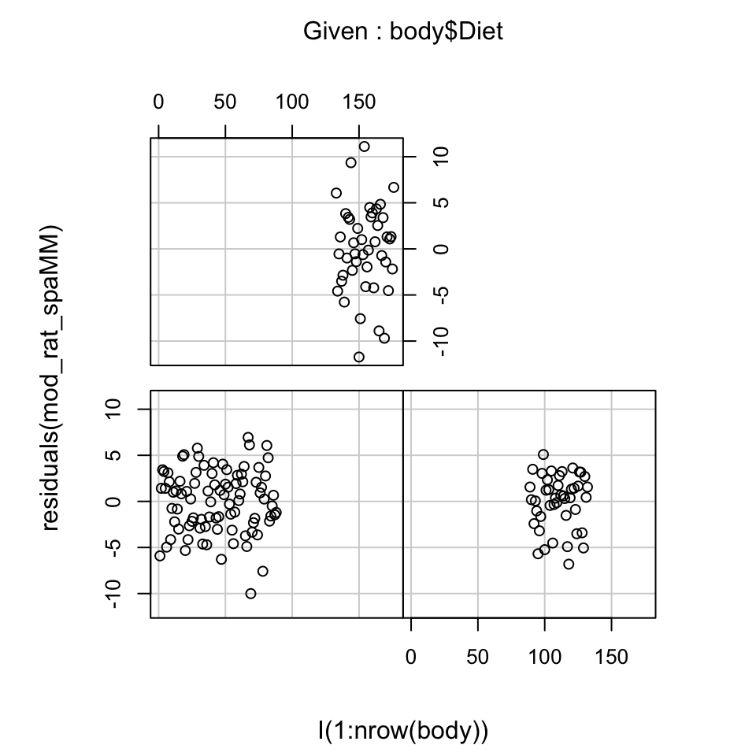

```r
coplot(residuals(mod_rat_spaMM) ~ I(1:nrow(body)) | body$Diet, show.given = FALSE)
```

## Let's revisit the rats

```r
mod_rat_hetero <- corrHLfit(weight ~ Diet * Time + (Time|Rat) + Matern(1|Time), data = body,
                           HLmethod = "REML", init.corrHLfit = list(Nugget = 0.1), ranFix = list(nu = 0.5),
                           resid.formula = ~ Diet)
```

```r
summary.tables <- summary(mod_rat_hetero)
```

```r
summary.tables$phi_table
```

```
##               Estimate  Cond. SE
## (Intercept)  2.6702155 0.1698757
## Diet2       -0.3221617 0.2961118
## Diet3        0.6638114 0.2918609
```

```r
print(rbind(AIC(mod_rat_spaMM),
            AIC(mod_rat_hetero)))
```

```
##        marginal AIC: 1176.1275
##     conditional AIC: 1035.8757
##      dispersion AIC: 1149.1142
##        effective df:  139.0042
##        marginal AIC: 1170.7321
##     conditional AIC: 1027.6438
##      dispersion AIC: 1143.6682
##        effective df:  138.8131
##             marginal AIC:     conditional AIC:      dispersion AIC:        effective df:
## [1,]             1176.127             1035.876             1149.114             139.0042
## [2,]             1170.732             1027.644             1143.668             138.8131
```

## Let's re-test the overal effect of the diet

```r
mod_rat_hetero <- corrHLfit(weight ~ Diet * Time + (Time|Rat) + Matern(1|Time), data = body,
                           HLmethod = "ML", init.corrHLfit = list(Nugget = 0.1), ranFix = list(nu = 0.5),
                           resid.formula = ~ Diet)

mod_rat_hetero0 <- corrHLfit(weight ~ Time + (Time|Rat) + Matern(1|Time), data = body,
                           HLmethod = "ML", init.corrHLfit = list(Nugget = 0.1), ranFix = list(nu = 0.5),
                           resid.formula = ~ Diet)

anova(mod_rat_hetero, mod_rat_hetero0)
```

```
##      chi2_LR df      p_value
## p_v 47.73391  4 1.072348e-09
```

## You can handle heteroscedasticity in simple models too!

```r
set.seed(1L)
d <- data.frame(y = c(rnorm(100, mean = 10, sd = sqrt(10)),
                      rnorm(100, mean = 20, sd = sqrt(20))),
                group = factor(c(rep("A", 100), rep("B", 100))))

m <- fitme(y ~ group, resid.model = ~ group, data = d, method = "REML")
unique(m$phi)
```

```
## [1]  8.067621 18.350646
```

## An example of many difficulties combined: `IsoriX`

## What is `IsoriX`?

```r
library(IsoriX)
```

## Loading the `GNIPDataDE` data

```r
dim(GNIPDataDE)
```

```
## [1] 8591    7
```

```r
head(GNIPDataDE)
```

```
##   stationID   lat long elev year month isoscape.value
## 1 SCHLESWIG 54.52 9.54   43 1997     6          -59.0
## 2 SCHLESWIG 54.52 9.54   43 1997     7          -56.0
## 3 SCHLESWIG 54.52 9.54   43 1997     8          -60.8
## 4 SCHLESWIG 54.52 9.54   43 1997     9          -51.0
## 5 SCHLESWIG 54.52 9.54   43 1997    10          -58.7
## 6 SCHLESWIG 54.52 9.54   43 1997    11          -74.6
```

## Aggregate the `GNIPDataDE`

```r
GNIPDataDE_agg <- prepdata(data = GNIPDataDE)
dim(GNIPDataDE_agg)
```

```
## [1] 27  7
```

```r
head(GNIPDataDE_agg)
```

```
##       stationID isoscape.value var.isoscape.value n.isoscape.value   lat  long elev
## 1        ARKONA      -60.99231           247.8767              134 54.67 13.43   42
## 2        ARTERN      -61.00653           510.5720              199 51.37 11.29  164
## 3 BAD SALZUFLEN      -53.80770           310.1046              408 52.10  8.75  135
## 4        BERLIN      -57.53477           395.6484              419 52.46 13.40   48
## 5  BRAUNSCHWEIG      -52.73350           339.4752              420 52.29 10.44   81
## 6      CUXHAVEN      -49.25271           221.6594              420 53.87  8.70    5
```

## `IsoriX` using `IsoriX`

```r
Europefit <- isofit(iso.data = GNIPDataDE_agg, mean.model.fix = list(elev = TRUE, lat.abs = TRUE))
```

```
## [1] Fitting the following residual dispersion model using spaMM  :
## [1] "var.isoscape.value ~ 1 + (1|stationID) + Matern(1|long + lat)"
## [1] (it may take a while...)
## [1] Fitting the following mean model using spaMM  :
## [1] "isoscape.value ~ 1 + elev + lat.abs + (1|stationID) + Matern(1|long + lat)"
## [1] (it may take a while...)
## [1] Done!
## [1] "Models were fitted in 7 sec."
```

## The data for the elevation

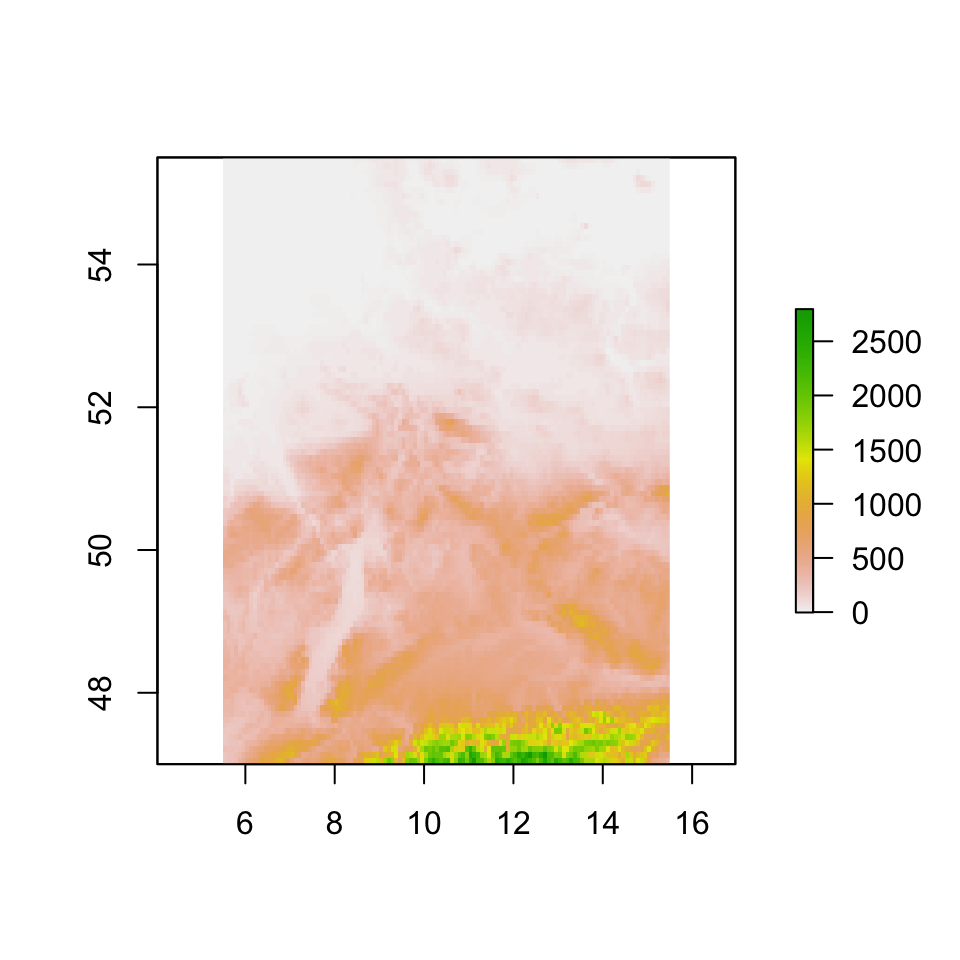

```r
library(rasterVis)
plot(ElevRasterDE)
```

## `IsoriX` using `IsoriX`

```r
isoscape <- isoscape(elevation.raster = ElevRasterDE, isofit = Europefit)
```

[output not shown]

```r
plot.mean <- plot(x = isoscape, which = "mean", plot = FALSE)

plot.disp <- plot(x = isoscape, which = "disp", plot = FALSE)
```

## Mean prediction of the distribution of Deuterium

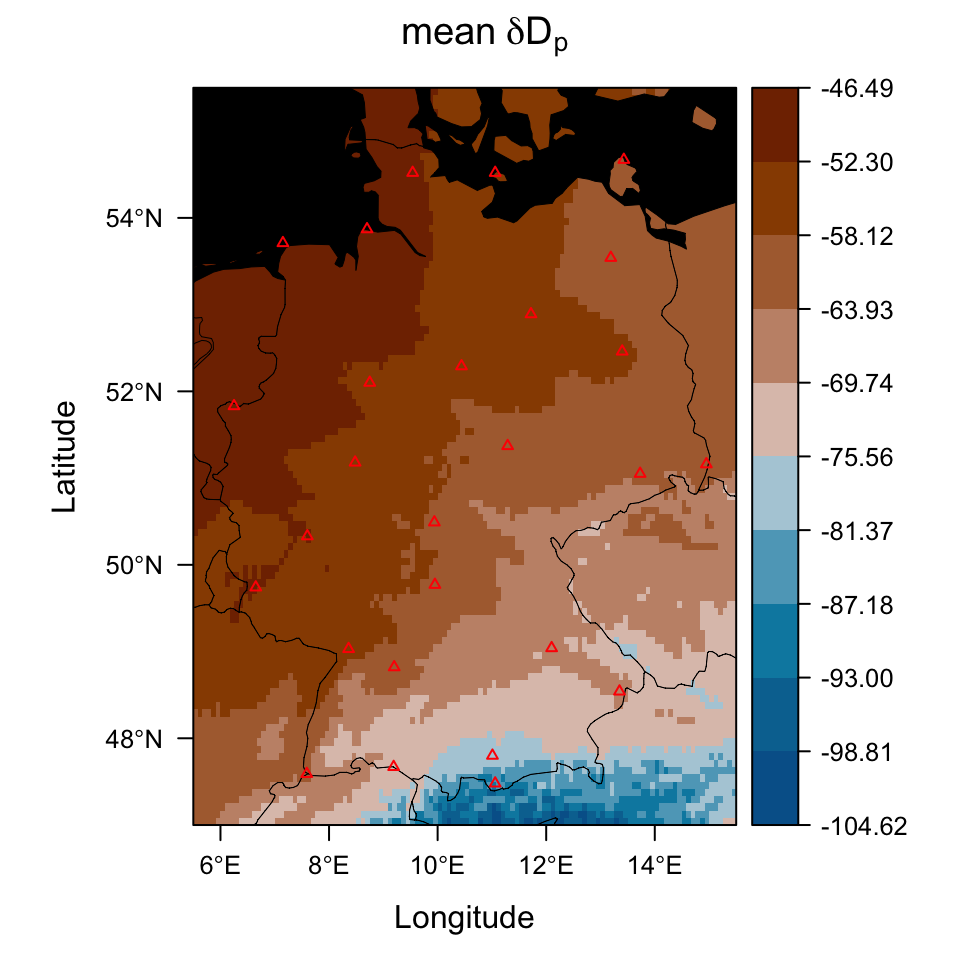

```r
plot.mean
```

## Prediction of the residual variance in Deuterium

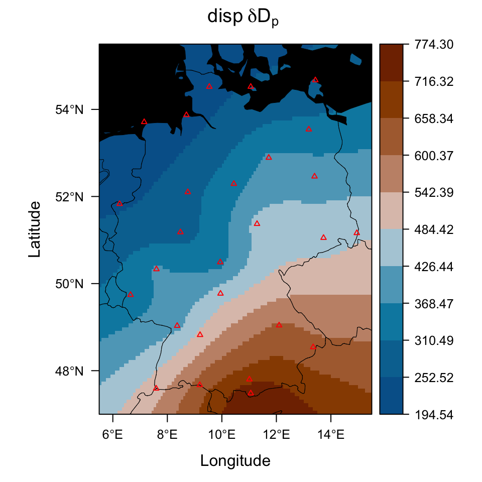

```r
plot.disp
```

## `IsoriX` using `spaMM`

```r
disp.fit <- fitme(var.isoscape.value ~ 1 + Matern(1 | long + lat), family = Gamma(log),
                  prior.weights = n.isoscape.value - 1, method = "REML", fixed = list(phi = 2),
                  control.dist = list(dist.method = "Earth"), data = GNIPDataDE_agg)
```

```r
GNIPDataDE_agg$pred.disp <- predict(disp.fit)[, 1]
```

```r
mean.fit <- fitme(isoscape.value ~ lat + elev + Matern(1 | long + lat), family = gaussian(),
                  prior.weights = n.isoscape.value, method = "REML",
                  resid.model = list(formula = ~ 0 + offset(pred.disp), family = Gamma(identity)),
                  control.dist = list(dist.method = "Earth"), data = GNIPDataDE_agg)
```

```r
Europefit2 <- list(mean.fit = mean.fit, disp.fit = disp.fit)
```

## Predictions

```r
isoscape2 <- isoscape(elevation.raster = ElevRasterDE, isofit = Europefit2)
```

[output not shown]

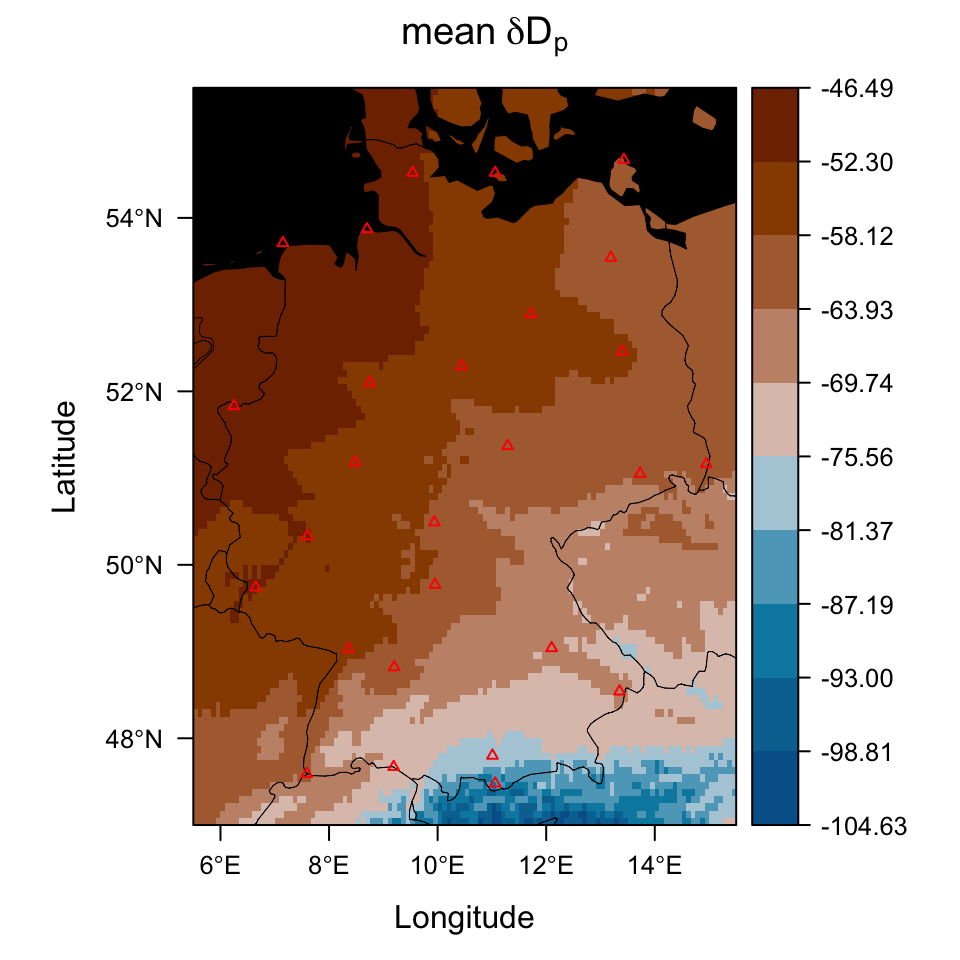

```r
plot(x = isoscape2, which = "mean", plot = TRUE)
```

## DHGLM

```r
system.time(
  dhglm <- corrHLfit(isoscape.value ~ lat + elev + Matern(1 | long + lat), family = gaussian(),
              HLmethod = "REML", data = GNIPDataDE, control.dist = list(dist.method = "Earth"),
              resid.model = list(formula = ~ 1 + Matern(1 | long + lat),
                                 control.dist = list(dist.method = "Earth"),
                                 family = Gamma(log), fixed = list(phi = 2)),
                                 verbose = c(TRACE = TRUE))
)
```

## What you need to remember

- how to handle temporal and spatial autocorrelation
- that GLMM are not very difficult if you already know GLM and LMM
- that random effects as well can have non Gaussian distribution
- that there are even more general methods than GLMM out there: HGLM and DHGLM
- how to handle heteroscedasticity

## Table of contents

## Mixed-effects models

- 4.0 Introduction
- 4.1 More extensions from simple LMM